# **Black Friday Analysis**

## **About our Data**:

- The dataset here is a sample of the transactions made in a retail store.
- The store wants to know better the customer purchase behaviour against different products.
- Specifically, here the problem is a regression problem where we are trying to predict the dependent variable (the amount of purchase) with the help of the information contained in the other variables.
- Things needed to be addressed:
  - Understanding the customers on the basis of their purchasing habits.
- Understanding the purchasing habits according to Age groups, Occuptation, City_Categories.
- The above segmented group of users can be then used to model the data and use to predict the purchase spend for each customer.
- Lets dive in by understanding the data.

selecting Data

# 1. Data Analysis

## **a. Let’s see how are our actually data looks like**

```
##    User_ID Product_ID Gender   Age Occupation City_Category
## 1  1000001  P00069042      F  0-17         10             A
## 2  1000001  P00248942      F  0-17         10             A
## 3  1000001  P00087842      F  0-17         10             A
## 4  1000001  P00085442      F  0-17         10             A
## 5  1000002  P00285442      M   55+         16             C
## 6  1000003  P00193542      M 26-35         15             A
## 7  1000004  P00184942      M 46-50          7             B
## 8  1000004  P00346142      M 46-50          7             B
## 9  1000004   P0097242      M 46-50          7             B
## 10 1000005  P00274942      M 26-35         20             A
##    Stay_In_Current_City_Years Marital_Status Product_Category_1
## 1                           2              0                  3
## 2                           2              0                  1
## 3                           2              0                 12
```

[output cut: 18 more lines]

### **Observations**:

- 1.If we observe The Id column values are repeated with same numbers and it won’t useful much in analysis
  - 2.Here age column data is distributed in interval range
  - 3.There are total3 city categories
  - 4.There are 3 different product Categories available to customers

## **B. Lets see the shape of our data**

```
## [1] 77776    12
```

## **c. Let’s get the Description of our Data**

```
## 'data.frame':  77776 obs. of  12 variables:
##  $ User_ID                   : int  1000001 1000001 1000001 1000001 1000002 1000003 1000004 1000004 1000004 1000005 ...
##  $ Product_ID                : chr  "P00069042" "P00248942" "P00087842" "P00085442" ...
##  $ Gender                    : chr  "F" "F" "F" "F" ...
##  $ Age                       : chr  "0-17" "0-17" "0-17" "0-17" ...
##  $ Occupation                : int  10 10 10 10 16 15 7 7 7 20 ...
##  $ City_Category             : chr  "A" "A" "A" "A" ...
##  $ Stay_In_Current_City_Years: chr  "2" "2" "2" "2" ...
##  $ Marital_Status            : int  0 0 0 0 0 0 1 1 1 1 ...
##  $ Product_Category_1        : int  3 1 12 12 8 1 1 1 1 8 ...
##  $ Product_Category_2        : int  NA 6 NA 14 NA 2 8 15 16 NA ...
##  $ Product_Category_3        : int  NA 14 NA NA NA NA 17 NA NA NA ...
##  $ Purchase                  : int  8370 15200 1422 1057 7969 15227 19215 15854 15686 7871 ...
```

### **Observations**:

- We have Categorical and Discrete Data in our Data set
- If we observe the Martial Status is of of Int where it should be Categorical
- Regarding product Categories We observe some missing values, we need to Handle those.

## **D. Let’s see the missing values present in our Data**

```
##                    User_ID                 Product_ID
##                          0                          0
##                     Gender                        Age
##                          0                          0
##                 Occupation              City_Category
##                          0                          0
## Stay_In_Current_City_Years             Marital_Status
##                          0                          0
##         Product_Category_1         Product_Category_2
##                          0                      24319
##         Product_Category_3                   Purchase
##                      54109                          0
```

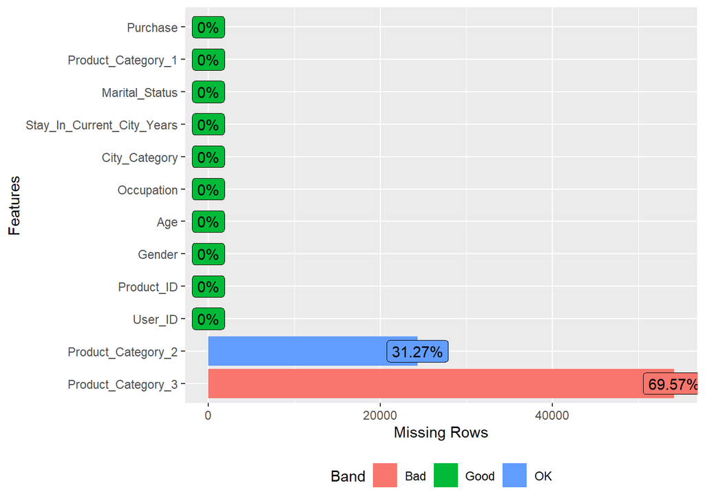

### **Observations** :

- We have missing values in Product_Category_2 and Product_category_3.

## **E.Now we’ll try to understand about variable distribution.**

- Continuous variables

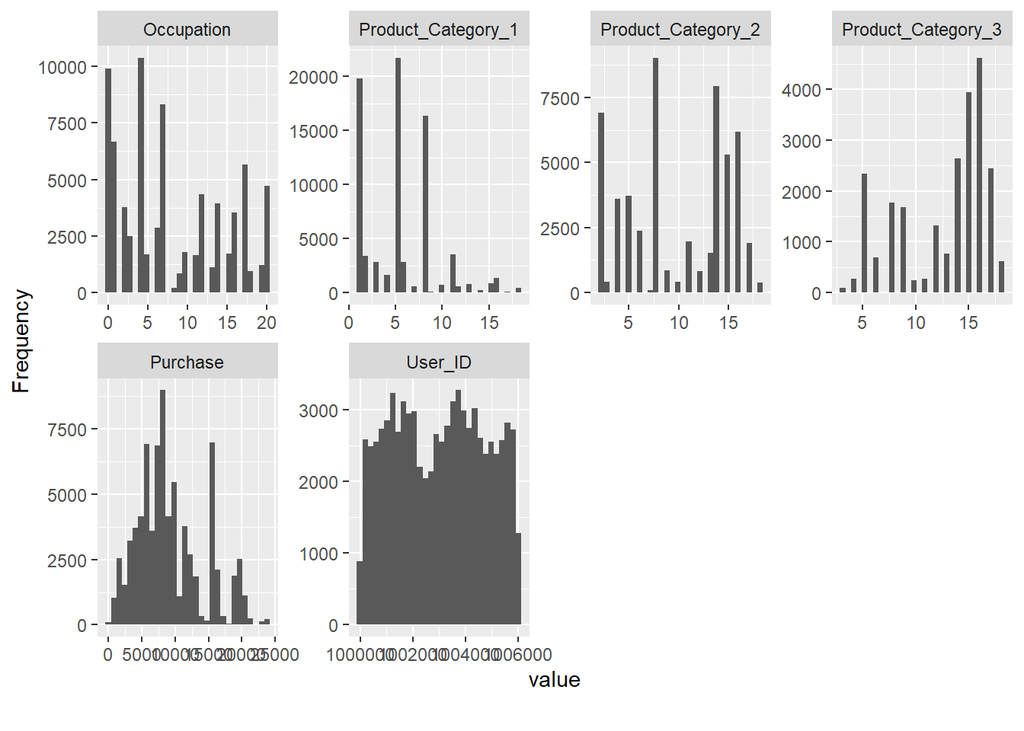

- Discrete variables
- Gender variable

```
##
##        F        M
## 0.243777 0.756223
```

- Customer Age group

```
##
##       0-17      18-25      26-35      36-45      46-50      51-55        55+
## 0.02691062 0.18528852 0.39813053 0.19940599 0.08107900 0.06989303 0.03929233
```

- Which city has highest customers

```
##
##         A         B         C
## 0.2695176 0.4220711 0.3084113
```

- Ration of category Stay_In_Current_City_Years

```
##
##         0         1         2         3        4+
## 0.1372531 0.3504037 0.1857642 0.1728940 0.1536849
```

## **Lets Draw the above Data via graphical intution**

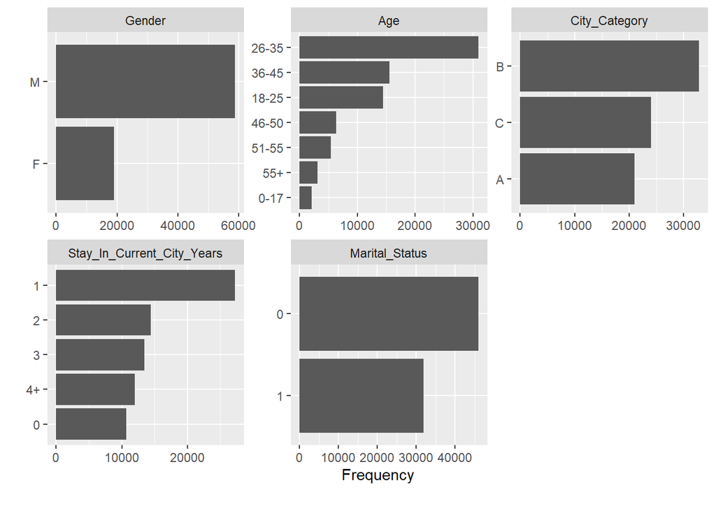

# 2. Data Transformation

Lets Transform Features of our Data their Respective Data Type

```r
sales$User_ID <- as.factor(sales$User_ID)
sales$Product_ID <- as.factor(sales$Product_ID)
sales$Age <- as.factor(sales$Age)
sales$Occupation <- as.factor(sales$Occupation)
sales$City_Category <- as.factor(sales$City_Category)
sales$Stay_In_Current_City_Years <- as.factor(sales$Stay_In_Current_City_Years)
sales$Product_Category_1 <- as.integer(sales$Product_Category_1)
sales$Product_Category_2 <- as.integer(sales$Product_Category_2)
sales$Product_Category_3 <- as.integer(sales$Product_Category_3)
sales$Purchase <- as.numeric(sales$Purchase)
```

# 3.Exploratory Data Analysis:

## Let’s See who have purchased more so lets draw a count plot for it

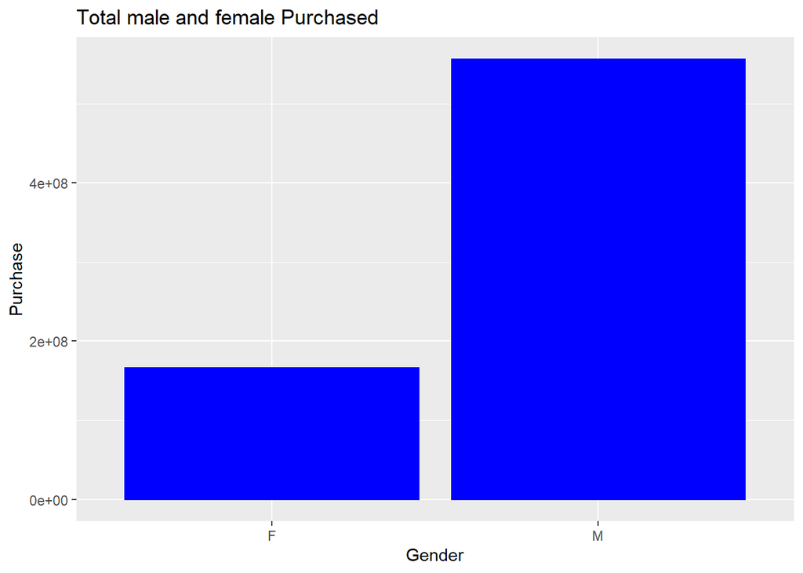

Male count is More compared to female count while black friday sales purchasing

## Similarly let’s see who have purchased more married or Unmarried

[figure not shown]

Unmarried have bought more than the married people

## **1.Age group/gender category vs product category**:

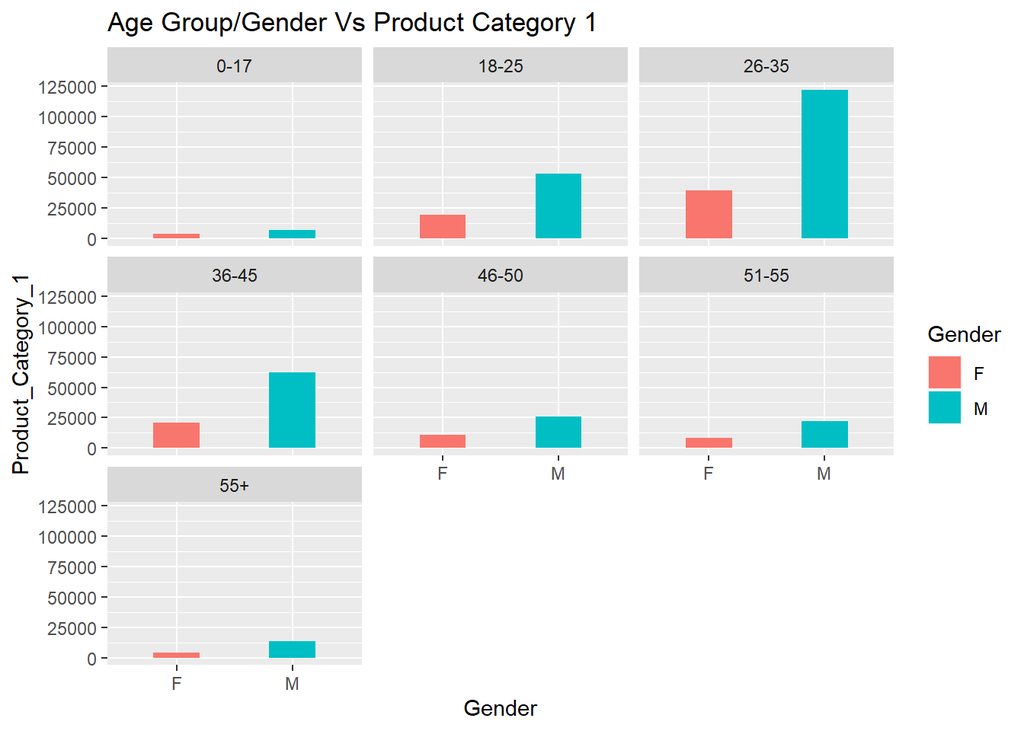

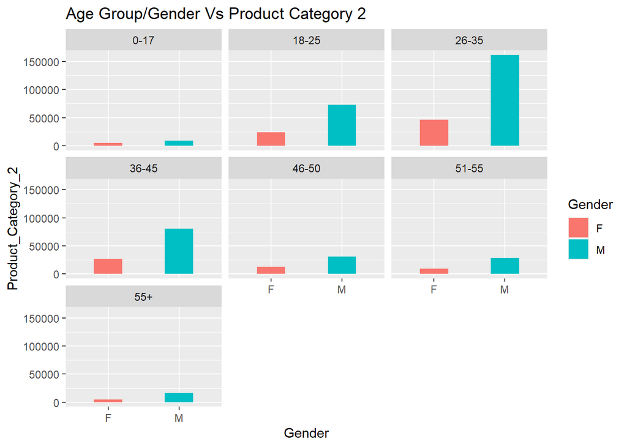

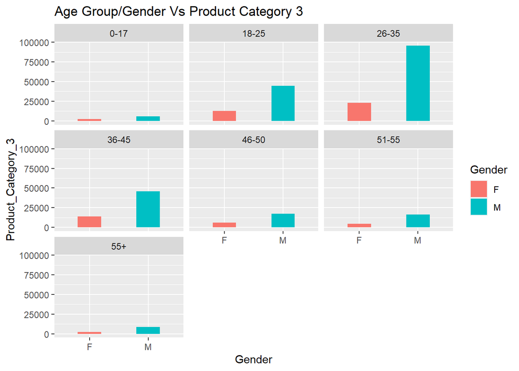

## **2. Occupation vs purchases**:

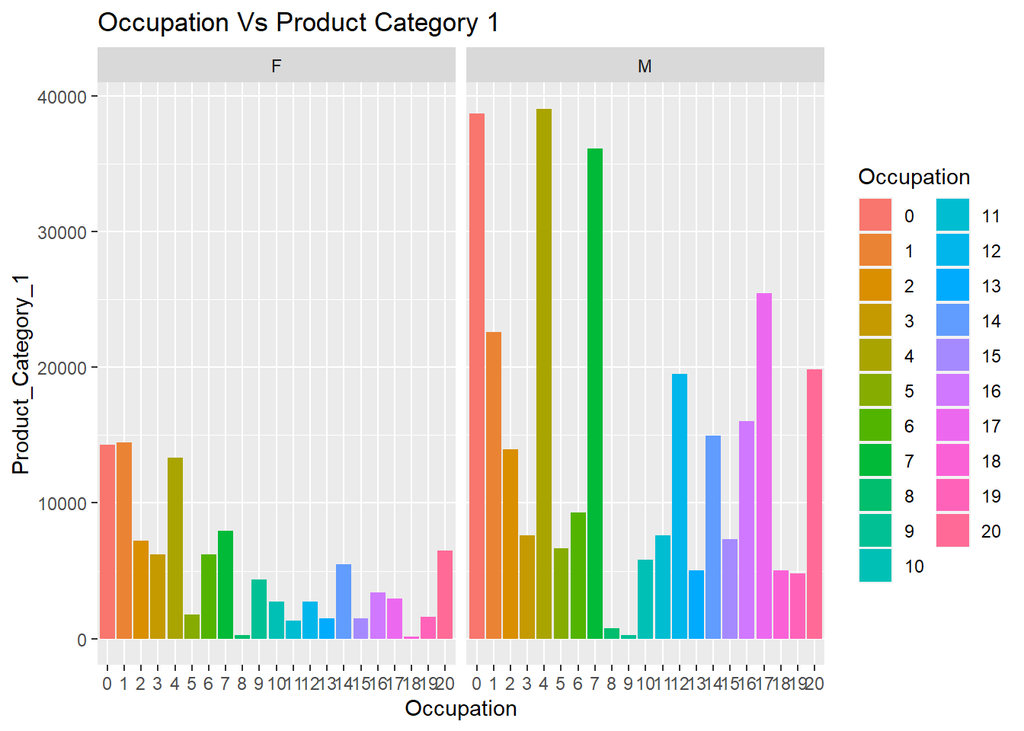

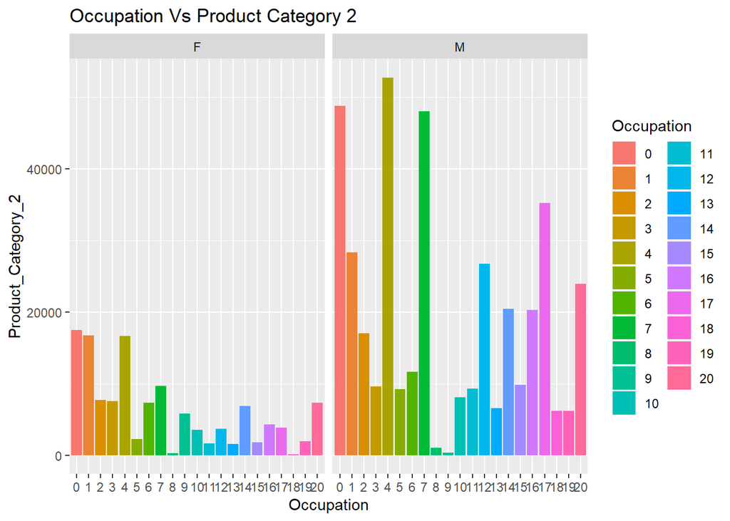

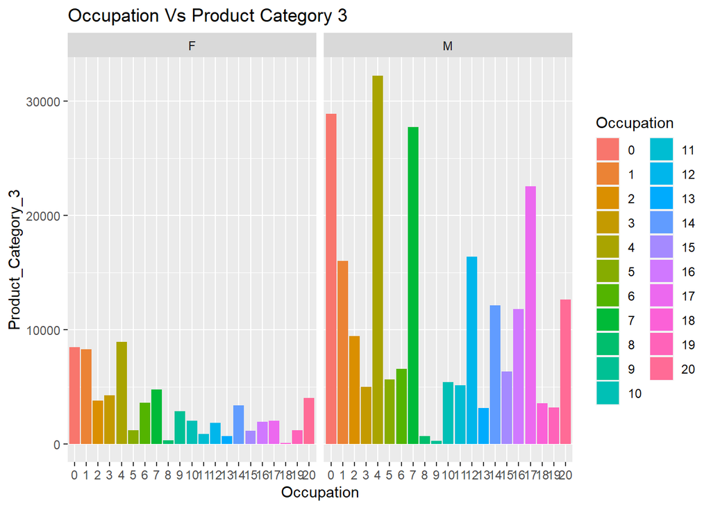

## **3. City Category vs Purchases:**

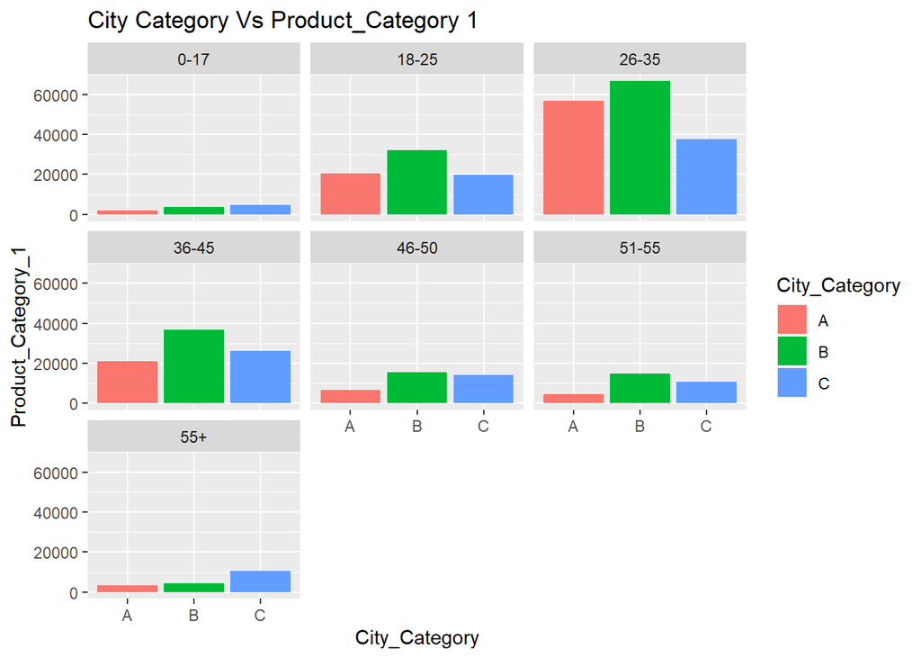

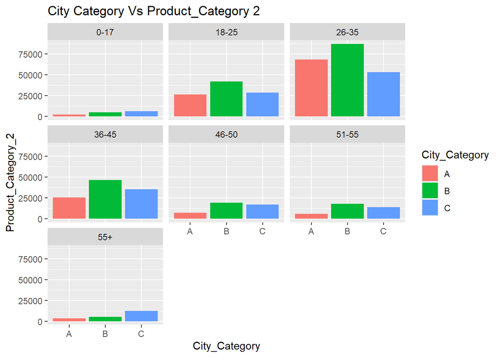

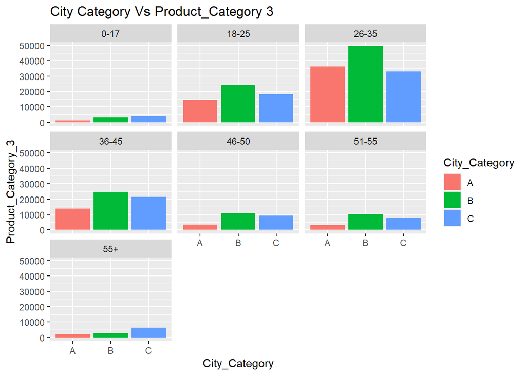

### **Observations:**

- People From city B with age group 26-35 have purchased most
- Then city A with the similar group of have done most purchases

## 4. Stay in cuntry vs product category and Purchase amount

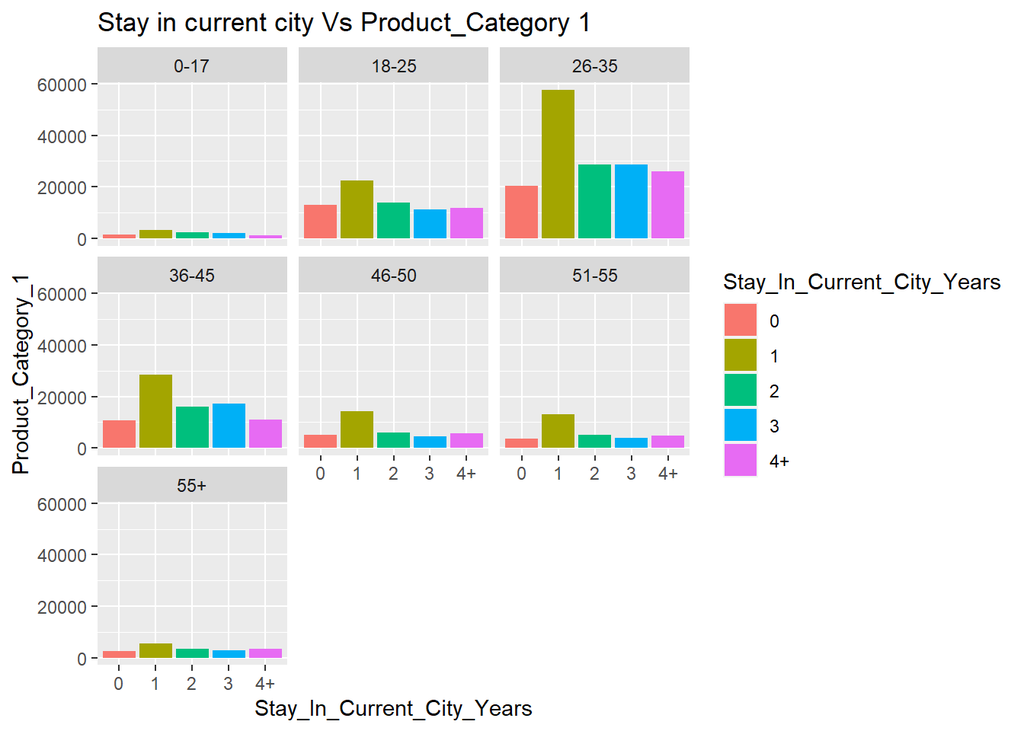

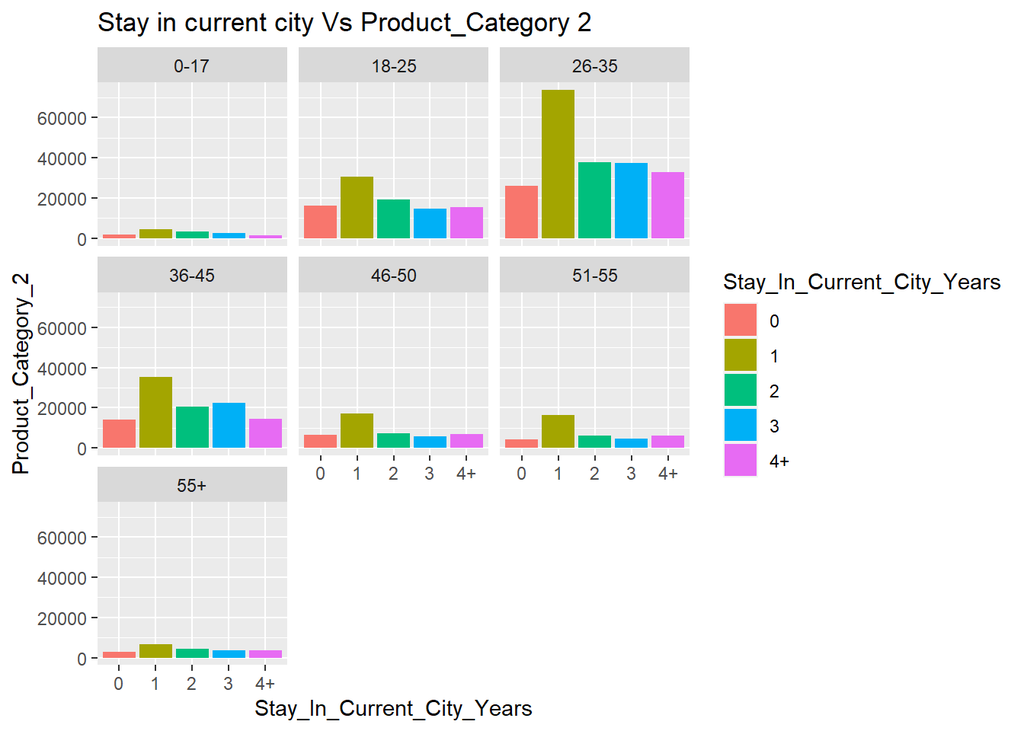

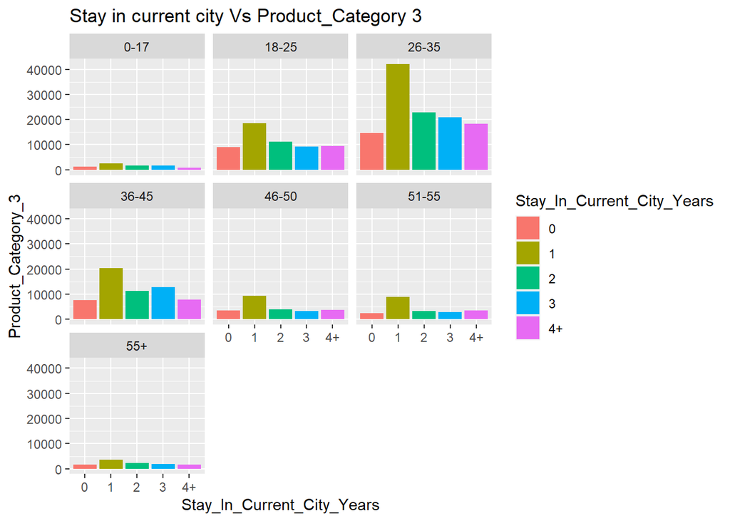

### **Observations:**

- People Staying with the period of one year and with age group 26-35 have done most purchases

## 6. Product Category vs Martial Status

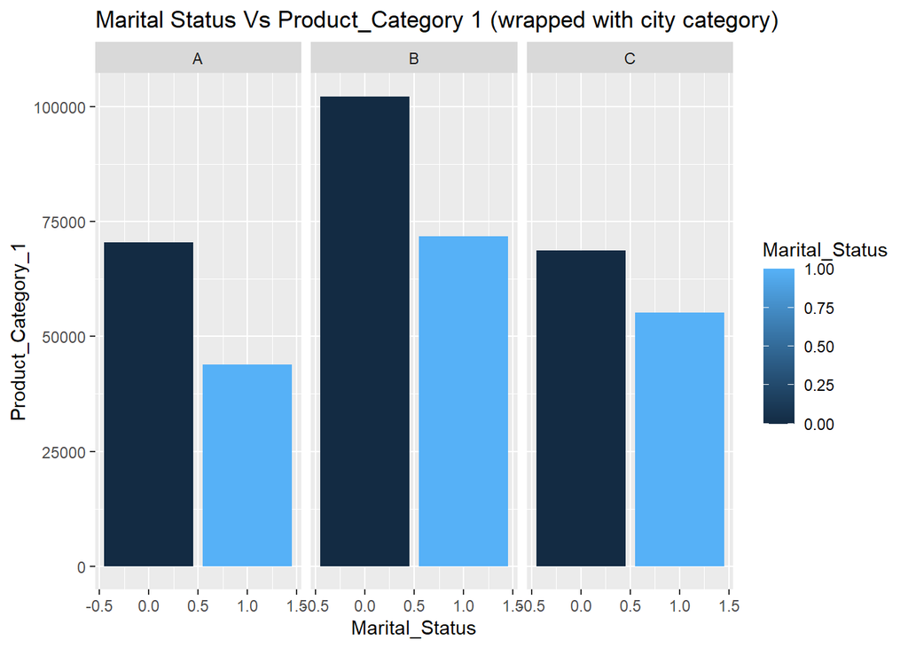

[figure not shown]

[figure not shown]

# Let’s see if there are any outliers with respect to Occupation data so we’ll draw boxplot for checking it

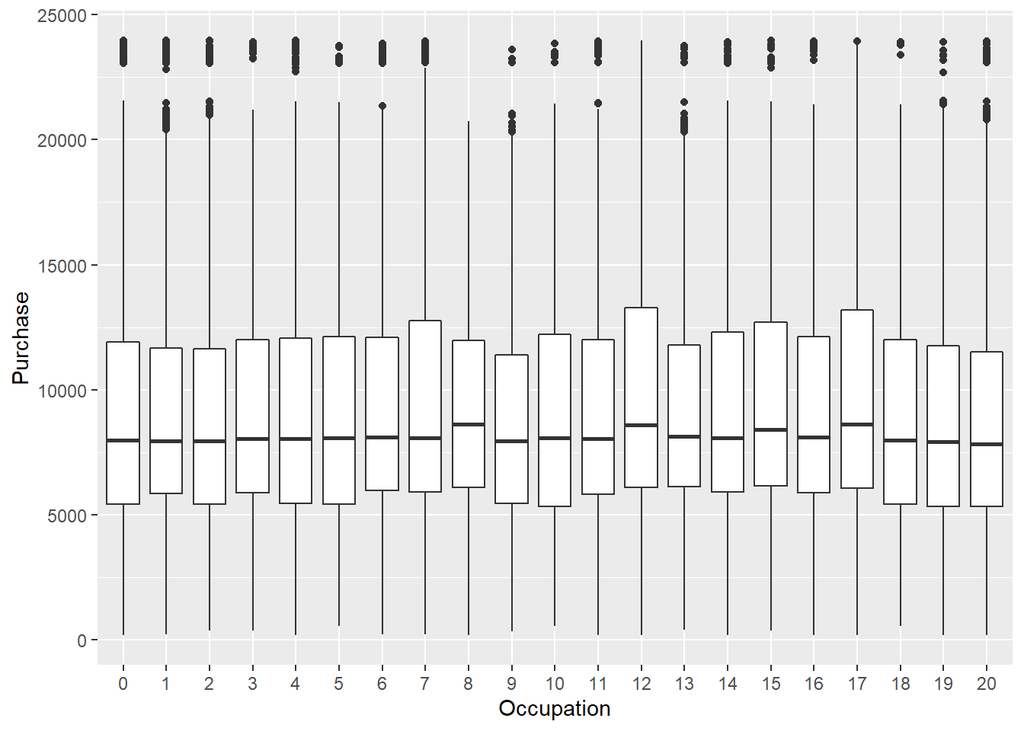

See We have few outliers in some areas of the Occupation

# Conclusion:

- CITY CATEGORY B HAD THE MOST CUSTOMERS(42%), FOLLOWED BY C (31%), AND LASTLY A (27%)
- PEOPLE WHO HAD STAYED IN THE CITY FOR 1 YEAR CONSTITUTED MAJORITY OF THE CUSTOMERS
- SINGLES MADE UP 59 % WHILE MARRIED MADE UP 41% OF THE CUSTOMERS
- AS EXPECTED 26-35 YEAR OLDS SPENT MORE MONEY
- IN ALL THE CITY CATEGORIES, THE SINGLES SPENT THE MOST MONEY
- FOR THE PRODUCT CATEGORIES WITH THE HIGHEST PURCHASE, THE PLOTS PRESENT THEM IN DETAILS